# 06b Figures: Map

J Andres Gannon and Cole Reynolds

2020-12-03

This document visualizes the geographic relationship between deterrence and the severity of Russian cyber operations.

# Preparation

## Load packages

Pipe operators have trouble loading for individual commands

## Load data

Load the cleaned and subset versions of each dataset

# Prior data maps

Map the data using prior variable codings from other datasets

## DCID

Map of the DCID cases showing variation in severity

```
14 codes from your data successfully matched countries in the map
0 codes from your data failed to match with a country code in the map
231 codes from the map weren't represented in your data
```

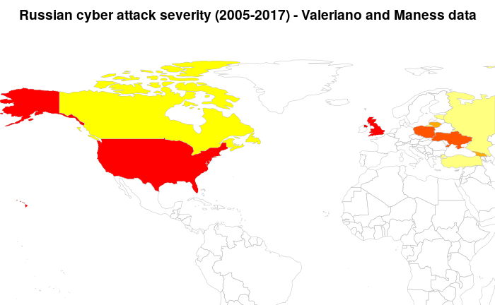

## REI

Map of the REI cases showing variation in severity. Info ops are coded as least severe, cyber disruption as moderate, and material support as most severe. Code each case by whatever is the most severe level that is present.

```
16 codes from your data successfully matched countries in the map
0 codes from your data failed to match with a country code in the map
227 codes from the map weren't represented in your data
```

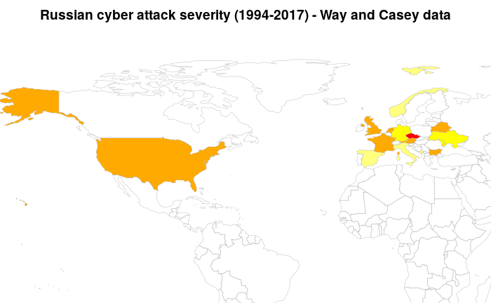

## Combined

There should only be one case that is coded in both DCID and REI. For all the rest, scale their scores so we get a single score for each case in either dataset and we can compare across datasets. We know this is a rough coding since one is coding severity of the cyber attack and the other is coding the type of attack, but we’ll start here.

# Current data maps

```
30 codes from your data successfully matched countries in the map
0 codes from your data failed to match with a country code in the map
217 codes from the map weren't represented in your data
```

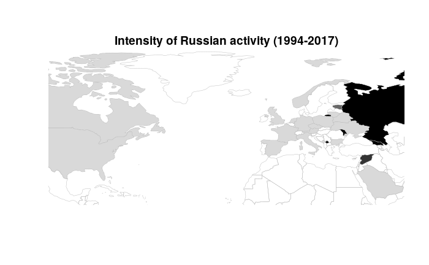

# New map

Create new dummy df

## Get geographic info

Only run once to get lat-lon data for each country to plot them

Merge new location info for each country

## Wrangle

We want a single column that is the highest value for each country

## Create new map

We can now make a new map where each country is colored with the highest intensity value

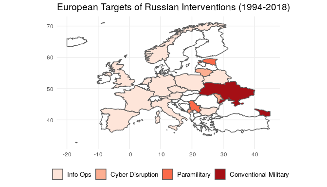